# Rwanda Baseline Demographic and Soil Summary

Matt Lowes

October 24, 2016

**Objective**: Summary of the demographics and soil characteristics of the Rwanda long term soil health study.

### Study methodology

```r
library(knitr)
library(ggplot2)
library(stringr)
suppressMessages(library(dplyr))
library(sp)
suppressMessages(library(dismo))
suppressMessages(library(stargazer))
library(leaflet)
library(XML)
```

```r
wd <- "/Users/mlowes/drive/soil health study/data/rw baseline"
dd <- paste(wd, "data", sep = "/")
od <- paste(wd, "output", sep="/")
drive <- "~/drive/r_help/4_output/statistical_test_outputs"

#load data:
# This data is being drawn from the Soil lab repository. It has the baseline data with it
d <- read.csv(paste(dd, "Rwanda_shs_commcare_soil data_final.csv", sep="/"),  stringsAsFactors=FALSE)
```

I’m using the merged data from Emmanuel for now but I will need to go back and download the demographic data fresh from Commcare and replicate the merge process using “Identifiers with SSN_final” provided by Emmanuel.

Included code to pair demographic and soil data?: **Not yet**

### Cleaning baseline variables

Now let’s start cleaning the demographic variables

```r
# take out weird CommCare stuff
d[d=="---"] <- NA

# take out demographic and text_final_question from variable names
#to.change <- c("text_final_questions.", "intro_champ_echantillon.",
#   "demographic_info.", "other_inputs_", "crop1_15b_inputs.", "crop2_15b_inputs.",
#   "^15b.", "historical_intro.")

#names(d) <- tapply(to.change, function(x) { gsub(x, "", names(d))})

names(d) <- gsub("text_fil_questions", "", names(d))
names(d) <- gsub("intro_champ_echantillon", "", names(d))
names(d) <- gsub("demographic_info", "", names(d))
names(d) <- gsub("other_inputs_", "", names(d))
names(d) <- gsub("crop1_15b_inputs", "", names(d))
names(d) <- gsub("crop2_15b_inputs", "", names(d))
names(d) <- gsub("^15b", "", names(d))
names(d) <- gsub("historical_intro", "", names(d))

names(d)[names(d)=="field_dim"] <- "field_dim1"
names(d)[names(d)=="v51"] <- "field_dim2"
```

Take care of demographic data formatting issues

```r
# deal with names and drop unnecessary variables
d <- d %>%
    dplyr::select(-c(rownumber, infoformid, introductiond_accept, photo,
        infocompleted_time,
        enumerator_me, contains("phone"), farmer_me, farmersurme, farmerme,
        d_respondent, additiolsamplepackedandsenttol, additiolsamplerequestedfromlab,
        datedryingcompleteifnecessary, driedindistrictifnecessary, senttohqyo,
        collectedindistrictyo, excessstoredathq_, receivedathq_,dateofinitialdryingifnecessary,
        samplecollectedinfieldyo, field_des, samplewetordry)) %>%
    rename(
    female = sex,
    age = age_cultivateur,
    own = d_own,
    client = d_client) %>%
    mutate(
    female= ifelse(female=="gore", 1,0),
    field.size = field_dim1*field_dim2
    )

d$total.seasons <- apply(d[, grep("d_season_list", names(d))], 1, function(x) {
    sum(x, na.rm=T)})
```

Fix some more variable names:

```r
names(d)[names(d)=="field_kg_fert1_1"] <- "field_kg_fert1_15b"
names(d)[names(d)=="field_kg_fert2_1"] <- "field_kg_fert2_15b"
names(d)[names(d)=="field_kg_compost"] <- "field_kg_compost_15b"
```

Recode variables to numeric:

```r
# recode to numeric
varlist <- c("client", "own", "crop1_15b_seedkg", "crop1_15b_yield", "crop1_15b_yield_",
    "crop2_15b_seedkg", "crop2_15b_yield", "crop2_15b_yield_", "field_kg_fert1_15b",
    "field_kg_fert2_15b", "field_kg_compost_15b", "d_lime_15b", "kg_lime_15b")

# check that there aren't values hidden in the character variables
#apply(d[,varlist], 2, function(x){table(x, useNA='ifany')})

# recode characters to numerics
d[, varlist] <- sapply(d[,varlist], as.numeric)

# divide out GPS coordinates
# http://rfunction.com/archives/1499

# replace the blank gps_pic_guide with info
d <- cbind(d, str_split_fixed(d$gps_pic_guid, " ", n=4))
names(d)[106:109] <- c("lat", "lon", "alt", "precision")
d[,c("lat", "lon", "alt", "precision")] <- sapply(d[,c("lat", "lon", "alt", "precision")],
                                                  function(x){as.numeric(as.character(x))})
```

Check out missing data in the district variable:

```r
table(d$district, useNA = 'ifany')
```

```
##
##               Gatsibo_LWH Gatsibo_NLWH     Gisagara         Huye
##           20          117          168           92          229
##      Karongi      Kayonza     Mugonero    Nyamagabe   Nyamasheke
##          323          113          261          112          299
##       Nyanza    Nyaruguru      Rutsiro      Rwamaga
##           93           92          332          223
```

```r
length(d[d$district=="",])
```

```
## [1] 109
```

```r
# these are the sample for which we have soil data but not survey data drop these for now
d <- d[-which(d$district==""),]
```

### Cleaning soil data

Cleaning of soil data: Come back, check and clean the soil data before outputting to clean data set. Plot each of the soil variables to look for unrealistic values.

```r
dim(d[is.na(d$m3.Ca),])
```

```
## [1]  11 109
```

```r
d <- d[-which(is.na(d$m3.Ca)),]

summary(d[,c("m3.Ca", "m3.Mg", "pH", "Total.N", "Total.C")])
```

```
##      m3.Ca            m3.Mg               pH           Total.N
##  Min.   : 220.5   Min.   :  38.26   Min.   :4.547   Min.   :0.05523
##  1st Qu.: 443.0   1st Qu.: 114.16   1st Qu.:5.021   1st Qu.:0.13596
##  Median : 720.2   Median : 184.98   Median :5.539   Median :0.15552
##  Mean   : 876.4   Mean   : 207.82   Mean   :5.544   Mean   :0.15717
##  3rd Qu.:1157.9   3rd Qu.: 270.26   3rd Qu.:6.009   3rd Qu.:0.17886
##  Max.   :3669.2   Max.   :1008.93   Max.   :7.211   Max.   :0.24701
##     Total.C
##  Min.   :0.8988
##  1st Qu.:1.7227
##  Median :2.1118
##  Mean   :2.1096
##  3rd Qu.:2.3657
##  Max.   :4.1620
```

Let’s check out the rows for which we don’t have soil data and drop them as they won’t contribute to the full picture.

### Graphs of RW baseline soil variables

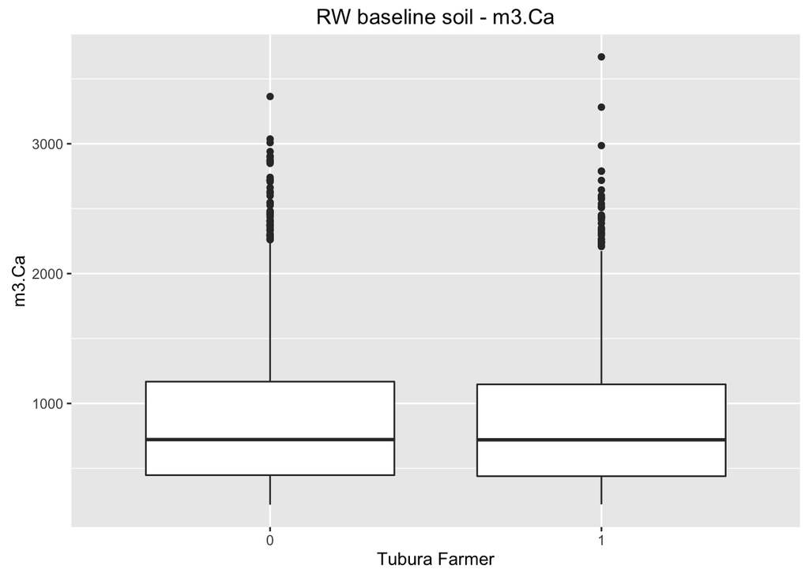

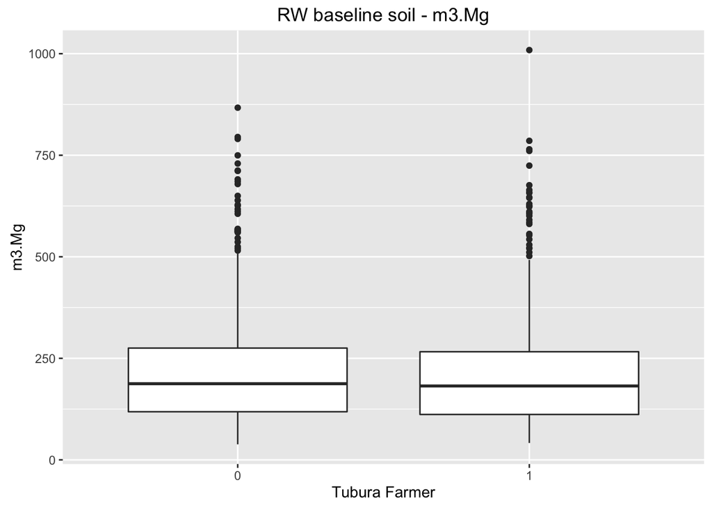

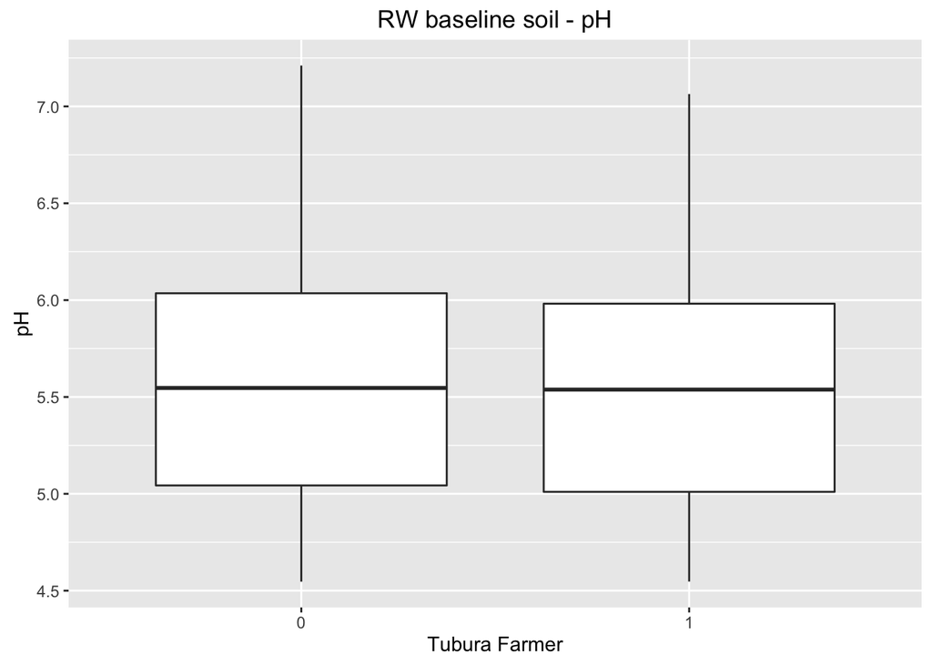

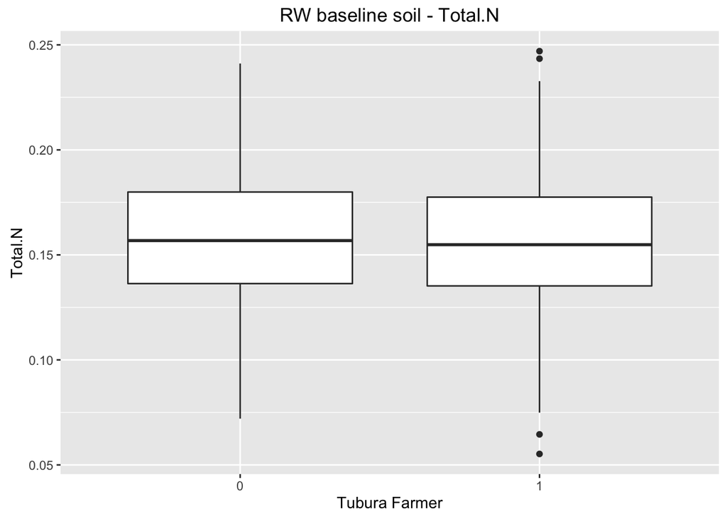

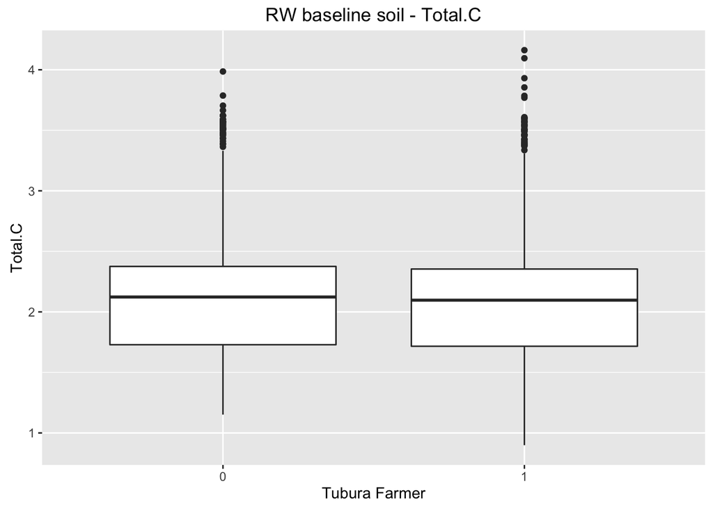

```r
soilVars <- c("m3.Ca", "m3.Mg", "pH", "Total.N", "Total.C")
for(i in 1:length(soilVars)){
print(
  ggplot(data=d, aes(x=as.factor(client), y=d[,soilVars[i]])) +
    geom_boxplot() +
    labs(x="Tubura Farmer", y=soilVars[i], title = paste("RW baseline soil - ", soilVars[i], sep = ""))
  )
}
```

Save clean demographic and soil data to external file

```r
write.csv(d, file=paste(paste(wd, "data", sep = "/"), "shs rw baseline.Rdata", sep = "/"))
save(d, file=paste(paste(wd, "data", sep = "/"), "shs rw baseline.Rdata", sep = "/"))
```

### Map of baseline observations

Produce a simple map of where our observations are

```r
e <- d[!is.na(d$lon),]
ss <- SpatialPointsDataFrame(coords = e[, c("lon", "lat")], data=e)
map <- leaflet() %>% addTiles() %>%
  setView(lng=rwanda$longitude, lat=rwanda$latitude, zoom=8) %>%
  addCircleMarkers(lng=ss$lon, lat=ss$lat, clusterOptions = markerClusterOptions())

map
```

[interactive chart not shown]

## Summary statistics

### Table of final baseline breakdown

```r
count <- d %>% group_by(district) %>%
  dplyr::summarize(
    t.count = sum(ifelse(client==1,1,0)),
    c.count = sum(ifelse(client==0,1,0)),
    total = n()
  ) %>% ungroup()

count <- as.data.frame(count)
write.csv(count, file=paste(od, "final rw sample breakdown.csv", sep="/"), row.names=F)
as.data.frame(count)
```

```
##        district t.count c.count total
## 1   Gatsibo_LWH      58      59   117
## 2  Gatsibo_NLWH      87      81   168
## 3      Gisagara      46      46    92
## 4          Huye     114     115   229
## 5       Karongi     163     159   322
## 6       Kayonza      55      58   113
## 7      Mugonero     131     129   260
## 8     Nyamagabe      56      56   112
## 9    Nyamasheke     147     146   293
## 10       Nyanza      46      46    92
## 11    Nyaruguru      46      46    92
## 12      Rutsiro     166     166   332
## 13      Rwamaga     110     111   221
```

## Baseline balance

```r
out.list <- c("female", "age", "hhsize", "own", "field.size",
              "n_season_fert", "n_season_compost", "n_season_lime", "n_season_fallow", "n_seasons_leg_1", "n_seasons_leg_2", "m3.Ca", "m3.Mg",
              "pH", "Total.C", "Total.N")

output <- do.call(rbind, lapply(out.list, function(x) {

  out <- t.test(d[,x] ~ d[,"client"], data=d)
  tab <- data.frame(out[[5]][[1]], out[[5]][[2]], out[3])
  tab[,1:2] <- round(tab[,1:2],3)
  names(tab) <- c(names(out[[5]]), "pvalue")
  return(tab)
}))

# use p.adjust with bonferroni correction
output$pvalue <- p.adjust(output$pvalue, method="fdr")
rownames(output) <- out.list
output <- output[order(output$pvalue),]
output$pvalue <- ifelse(output[, 3] < 0.001, "< 0.001", round(output[, 3], 3))


colnames(output) <- c("Non-Tubura", "Tubura Client", "p-value")
```

```r
print(kable(output))
```

|  | Non-Tubura | Tubura Client | p-value |
| --- | --- | --- | --- |
| n_season_fert | 0.833 | 3.260 | < 0.001 |
| female | 0.649 | 0.493 | < 0.001 |
| age | 48.111 | 44.002 | < 0.001 |
| hhsize | 4.896 | 5.416 | < 0.001 |
| n_season_lime | 0.132 | 0.228 | < 0.001 |
| own | 0.956 | 0.932 | 0.024 |
| n_season_compost | 5.523 | 5.818 | 0.126 |
| n_season_fallow | 0.570 | 0.690 | 0.136 |
| Total.N | 0.158 | 0.156 | 0.138 |
| m3.Ca | 894.242 | 858.574 | 0.157 |
| m3.Mg | 211.917 | 203.756 | 0.157 |
| field.size | 602.096 | 667.258 | 0.214 |
| pH | 5.556 | 5.532 | 0.348 |
| Total.C | 2.120 | 2.099 | 0.348 |
| n_seasons_leg_1 | 2.130 | 2.233 | 0.374 |
| n_seasons_leg_2 | 3.352 | 5.398 | 0.453 |

```r
#write table
write.csv(output, file=paste(od, "baseline balance.csv", sep="/"), row.names=T)
```

### Overall balance interpretation

**Demographic variables** We are not well balanced along the main demographic variables we collected, sex, age and HH size. For the purposes of inference we can test some matching algorithms to improve the match between Tubura and control farmers.

**Soil Variables** We are balanced on the primary soil variables of interest betwen our Tubura farmers and the comparison farmers.

### Baseline balance by district

```r
dist.output <- do.call(rbind, lapply(split(d, d$district), function(x) {

  tab <- do.call(rbind, lapply(out.list, function(y) {

    out <- t.test(x[,y] ~ x[,"client"], data=x)
    tab <- data.frame(out[[5]][[1]], out[[5]][[2]], out[3])
    tab[,1:2] <- round(tab[,1:2],3)
    names(tab) <- c(names(out[[5]]), "pvalue")
    #tab[,3] <- p.adjust(tab[,3], method="holm")
    #tab[,3] <- ifelse(tab[,3] < 0.001, "< 0.001", round(tab[,3],3))
    #print(tab)
    return(tab)
  }))

  return(data.frame(district = unique(x$district), tab))
}))

rownames(dist.output) <- NULL
dist.output$variable <- rep(out.list,13)

# order variables
dist.output <- dist.output[, c(1, 5, 2:4)]
dist.output$pvalue <- p.adjust(dist.output$pvalue, method="fdr")
dist.output <- dist.output[order(dist.output$pvalue),]

dist.output$pvalue <- ifelse(dist.output$pvalue < 0.001, "< 0.001", round(dist.output$pvalue,3))
colnames(dist.output) <- c("District", "Varible", "Non-Tubura", "Tubura Client", "p-value")
```

```r
print(kable(dist.output))
```

|  | District | Varible | Non-Tubura | Tubura Client | p-value |
| --- | --- | --- | --- | --- | --- |
| 70 | Karongi | n_season_fert | 0.447 | 3.785 | < 0.001 |
| 102 | Mugonero | n_season_fert | 0.597 | 4.313 | < 0.001 |
| 182 | Rutsiro | n_season_fert | 1.072 | 4.175 | < 0.001 |
| 134 | Nyamasheke | n_season_fert | 1.507 | 5.068 | < 0.001 |
| 198 | Rwamaga | n_season_fert | 1.054 | 2.645 | < 0.001 |
| 54 | Huye | n_season_fert | 0.322 | 2.246 | < 0.001 |
| 22 | Gatsibo_NLWH | n_season_fert | 0.296 | 1.517 | < 0.001 |
| 118 | Nyamagabe | n_season_fert | 1.554 | 4.000 | < 0.001 |
| 136 | Nyamasheke | n_season_lime | 0.041 | 0.327 | < 0.001 |
| 86 | Kayonza | n_season_fert | 0.776 | 2.073 | < 0.001 |
| 194 | Rwamaga | age | 52.072 | 44.245 | 0.001 |
| 131 | Nyamasheke | hhsize | 4.685 | 5.701 | 0.003 |
| 65 | Karongi | female | 0.667 | 0.466 | 0.004 |
| 163 | Nyaruguru | hhsize | 4.717 | 6.217 | 0.004 |
| 45 | Gisagara | m3.Mg | 241.171 | 190.036 | 0.006 |
| 50 | Huye | age | 49.400 | 43.395 | 0.009 |
| 44 | Gisagara | m3.Ca | 1203.823 | 895.928 | 0.01 |
| 145 | Nyanza | female | 0.543 | 0.217 | 0.012 |
| 150 | Nyanza | n_season_fert | 0.152 | 1.326 | 0.019 |
| 18 | Gatsibo_NLWH | age | 46.210 | 39.897 | 0.019 |
| 17 | Gatsibo_NLWH | female | 0.556 | 0.322 | 0.021 |
| 2 | Gatsibo_LWH | age | 49.949 | 41.931 | 0.027 |
| 113 | Nyamagabe | female | 0.750 | 0.482 | 0.03 |
| 81 | Kayonza | female | 0.672 | 0.400 | 0.03 |
| 20 | Gatsibo_NLWH | own | 1.000 | 0.908 | 0.031 |
| 104 | Mugonero | n_season_lime | 0.023 | 0.176 | 0.031 |
| 193 | Rwamaga | female | 0.739 | 0.555 | 0.031 |
| 1 | Gatsibo_LWH | female | 0.492 | 0.241 | 0.035 |
| 179 | Rutsiro | hhsize | 4.855 | 5.608 | 0.046 |
| 99 | Mugonero | hhsize | 5.054 | 5.802 | 0.049 |

[output cut: 178 more lines]

### District balance interpretation

```r
write.csv(dist.output, file=paste(od, "district balance.csv", sep="/"), row.names=T)
```

### Baseline balance by Tubura tenure

Look at farmers by duration of tenure farming with Tubura. We want to understand, at least with an initial naive baseline sense, what is the cumulative effect of Tubura practices on soil health outcomes?

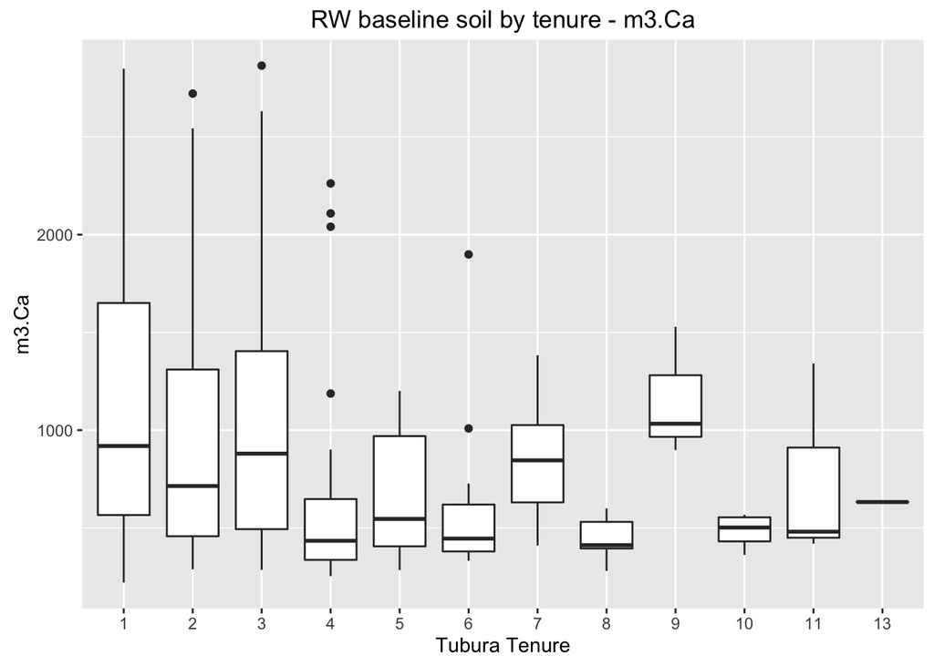

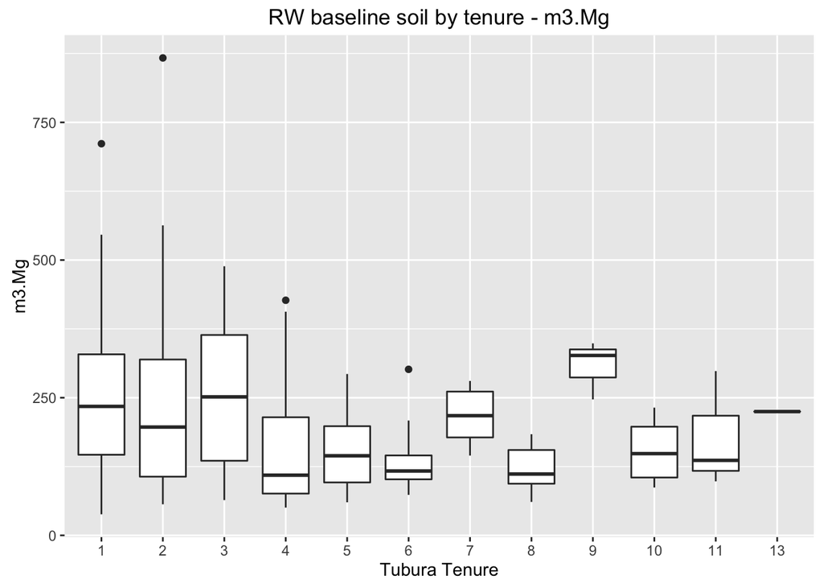

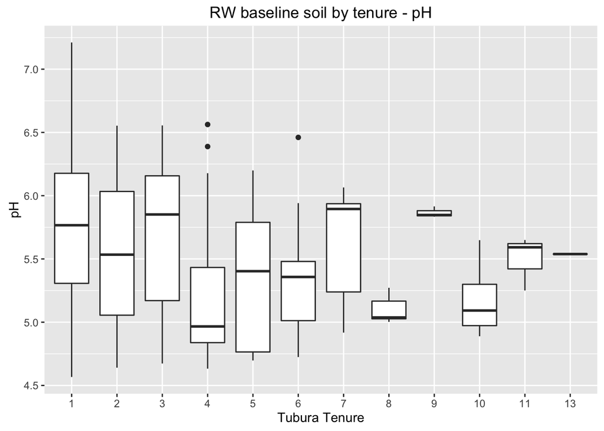

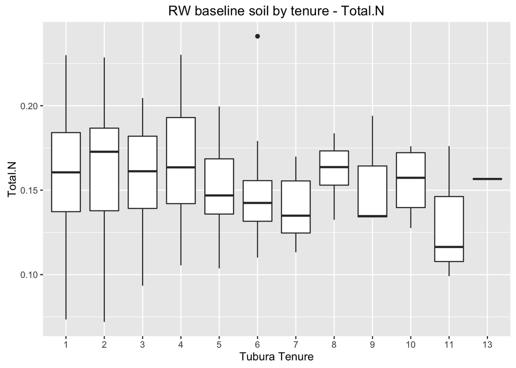

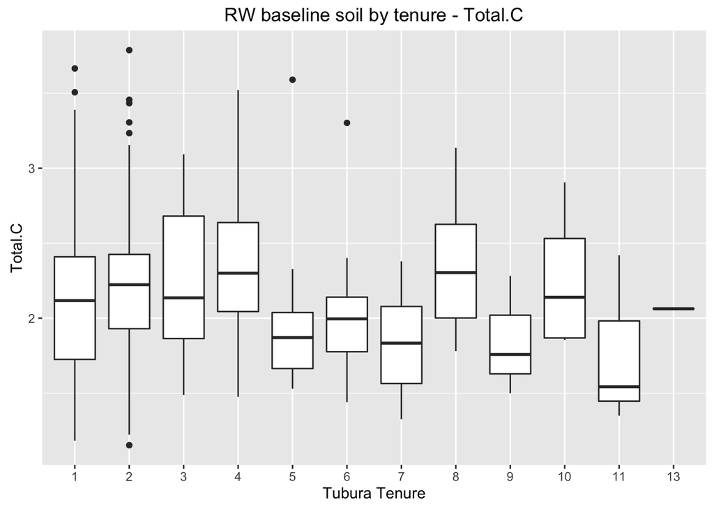

```r
oafOnly <- d[which(d$client==0 & d$total.seasons>=1),]
for(i in 1:length(soilVars)){
print(
  ggplot(oafOnly, aes(x=as.factor(total.seasons), y=oafOnly[,soilVars[i]])) +
    geom_boxplot() +
    labs(x="Tubura Tenure", y=soilVars[i], title = paste("RW baseline soil by tenure - ", soilVars[i], sep = ""))
  )
}
```

### Tenure summaries

```r
tenureSum <- aggregate(oafOnly[,out.list], by=list(oafOnly$total.seasons), function(x){
  round(mean(x, na.rm=T),2)
})
tenureSum <- as.data.frame(t(tenureSum))
colnames(tenureSum) <- c(paste(seq(1,11,1), " seas.", sep = ""), "13 seas.")
```

```r
print(kable(tenureSum))
```

|  | 1 seas. | 2 seas. | 3 seas. | 4 seas. | 5 seas. | 6 seas. | 7 seas. | 8 seas. | 9 seas. | 10 seas. | 11 seas. | 13 seas. |
| --- | --- | --- | --- | --- | --- | --- | --- | --- | --- | --- | --- | --- |
| Group.1 | 1.00 | 2.00 | 3.00 | 4.00 | 5.00 | 6.00 | 7.00 | 8.00 | 9.00 | 10.00 | 11.00 | 13.00 |
| female | 0.70 | 0.61 | 0.67 | 0.65 | 0.64 | 0.58 | 0.75 | 0.33 | 0.33 | 0.75 | 0.67 | 0.00 |
| age | 48.77 | 46.43 | 46.46 | 48.96 | 42.73 | 43.83 | 42.12 | 52.33 | 36.00 | 48.50 | 42.00 | 52.00 |
| hhsize | 5.30 | 5.40 | 5.71 | 4.91 | 6.09 | 5.25 | 5.50 | 5.83 | 6.67 | 6.50 | 8.67 | 6.00 |
| own | 0.92 | 0.97 | 1.00 | 1.00 | 0.91 | 1.00 | 1.00 | 0.83 | 1.00 | 1.00 | 1.00 | 1.00 |
| field.size | 564.72 | 595.76 | 390.17 | 547.13 | 976.18 | 289.17 | 346.75 | 602.33 | 256.00 | 241.00 | 334.67 | 480.00 |
| n_season_fert | 1.03 | 1.27 | 3.17 | 1.65 | 1.82 | 2.83 | 2.38 | 5.33 | 2.67 | 3.75 | 0.33 | 10.00 |
| n_season_compost | 5.48 | 5.61 | 6.58 | 4.43 | 5.82 | 6.50 | 6.75 | 8.33 | 10.00 | 8.25 | 4.67 | 10.00 |
| n_season_lime | 0.27 | 0.17 | 0.25 | 0.09 | 0.18 | 0.33 | 0.00 | 0.17 | 0.00 | 0.00 | 0.00 | 0.00 |
| n_season_fallow | 0.53 | 0.74 | 0.58 | 1.00 | 0.45 | 0.50 | 0.88 | 0.00 | 0.00 | 0.00 | 1.33 | 0.00 |
| n_seasons_leg_1 | 2.12 | 2.14 | 1.96 | 2.00 | 1.55 | 1.25 | 0.62 | 3.00 | 4.00 | 2.25 | 4.33 | 1.00 |
| n_seasons_leg_2 | 3.13 | 2.85 | 4.50 | 2.57 | 6.27 | 2.33 | 5.88 | 3.50 | 3.33 | 5.25 | 0.00 | 9.00 |
| m3.Ca | 1127.45 | 946.96 | 1034.46 | 686.67 | 678.56 | 625.67 | 870.40 | 443.64 | 1153.25 | 483.06 | 746.88 | 632.20 |
| m3.Mg | 247.35 | 226.65 | 252.39 | 165.35 | 153.59 | 138.80 | 217.69 | 120.77 | 307.42 | 153.92 | 177.55 | 224.80 |
| pH | 5.72 | 5.56 | 5.70 | 5.20 | 5.34 | 5.34 | 5.64 | 5.10 | 5.87 | 5.18 | 5.50 | 5.54 |
| Total.C | 2.13 | 2.19 | 2.19 | 2.36 | 2.01 | 2.06 | 1.83 | 2.36 | 1.85 | 2.26 | 1.77 | 2.06 |
| Total.N | 0.16 | 0.16 | 0.16 | 0.17 | 0.15 | 0.15 | 0.14 | 0.16 | 0.15 | 0.15 | 0.13 | 0.16 |

```r
oafOnly$tenured <- ifelse(oafOnly$total.seasons==1,0,1)

tenure <- do.call(rbind, lapply(out.list, function(x) {

  out <- t.test(oafOnly[,x] ~ oafOnly[,"tenured"], data=oafOnly)
  tab <- data.frame(out[[5]][[1]], out[[5]][[2]], out[3])
  tab[,1:2] <- round(tab[,1:2],3)
  names(tab) <- c(names(out[[5]]), "pvalue")
  return(tab)
}))

# use p.adjust with bonferroni correction
tenure$pvalue <- p.adjust(tenure$pvalue, method="fdr")
rownames(tenure) <- out.list
tenure <- tenure[order(tenure$pvalue),]
tenure$pvalue <- ifelse(tenure[, 3] < 0.001, "< 0.001", round(tenure[, 3], 3))


colnames(tenure) <- c("Non-Tubura", "Tubura Client", "p-value")
```

```r
print(kable(tenure))
```

|  | Non-Tubura | Tubura Client | p-value |
| --- | --- | --- | --- |
| n_season_fert | 1.032 | 1.944 | < 0.001 |
| m3.Ca | 1127.451 | 863.314 | 0.003 |
| pH | 5.724 | 5.492 | 0.003 |
| m3.Mg | 247.352 | 208.608 | 0.033 |
| n_season_lime | 0.272 | 0.162 | 0.105 |
| own | 0.920 | 0.975 | 0.115 |
| female | 0.704 | 0.614 | 0.219 |
| age | 48.768 | 46.213 | 0.235 |
| n_season_compost | 5.480 | 5.914 | 0.56 |
| hhsize | 5.304 | 5.523 | 0.574 |
| n_season_fallow | 0.528 | 0.680 | 0.574 |
| Total.C | 2.127 | 2.170 | 0.602 |
| n_seasons_leg_2 | 3.128 | 3.365 | 0.746 |
| field.size | 564.724 | 540.751 | 0.833 |
| n_seasons_leg_1 | 2.120 | 2.036 | 0.833 |
| Total.N | 0.160 | 0.160 | 0.835 |

### Tenured v. new balance interpretation

Tubura tenure is being defined here as having more than 1 year experience farming with Tubura.

**Demographic variables** We are well balanced along demographic variables.

**Agricultural practice variables** Not surprisingly, Tubura farmers have more cumulative years of fertilizer use than current non-Tubura farmers. While that difference is signficant, it is realistically only a single season of fertilizer use different.

**Soil Variables** Soil pH, calcium and magnesium levels are lower for tenured Tubura farmers. This is consistent with the hypothesis that increaesd fertilizer use leads to an increaese in soil acidity.

### Analysis of agronomic practices contributing to soil health outcomes

Here’s where we’ll look at fertilizer, lime and cultivation practices on soil health outcomes. This analysis will be come richer as we gain longitudinal measures.

–end